# Data science per psicologi - demo 11.01

Corrado Caudek

2022-03-22

```r
suppressPackageStartupMessages({
  library("here")
  library("tidyverse")
  library("scales")
  library("bayesplot")
})

theme_set(bayesplot::theme_default(base_size = 12))
bayesplot::color_scheme_set("gray")
set.seed(84735)

knitr::opts_chunk$set(
  collapse = TRUE,
  tidy = 'styler',
  fig.width = 6,
  fig.asp = 0.618 # 1 / phi
)
```

# Interpretazione del valore atteso e della varianza di una variabile casuale

Supponiamo di sapere che, sulla base dei dati di un campione molto grande, possiamo stabilire che nella popolazione oncologica, i punteggi di un test psicometrico atto a misurare l’astenia seguono la *distribuzione di massa di probabilità* indicata qui sotto:

| Punteggio | Probabilità |
| --- | --- |
| 1 | 0.1 |
| 2 | 0.5 |
| 3 | 0.3 |
| 4 | 0.1 |

Laddove i valori indicano la frequenza con la quale tale sintomo, riduzione di energia dell’individuo, si manifesta. Per esempio, potremmo avere che `4` corrisponde a “molto spesso”, `3` corrisponde a “spesso”, `2` corrisponde a “alle volte” e `1` corrisponde a “raramente o mai”.

## Rappresentazione grafica della distribuzione di massa di probabilità

Abbiamo dunque i valori $Y$

```r
y <- 1:4
```

con probabilità

```r
py <- c(0.1, 0.5, 0.3, 0.1)
```

Credo un DataFrame con queste informazioni

```r
d <- tibble(y, py)
d
```

```
## # A tibble: 4 × 2
##       y    py
##   <int> <dbl>
## 1     1   0.1
## 2     2   0.5
## 3     3   0.3
## 4     4   0.1
```

Rappresento in maniera grafica la distribuzione di massa di probabilità della $Y$:

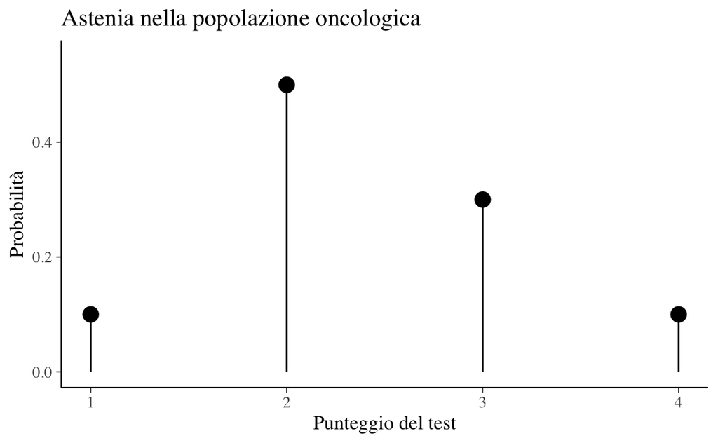

```r
d %>%
  ggplot(aes(y, py)) +
  geom_point(size = 4) +
  geom_linerange(aes(x = y, ymax = py, ymin = 0.0)) +
  ylim(0, 0.55) +
  labs(
    title = "Astenia nella popolazione oncologica",
    x = "Punteggio del test",
    y = "Probabilità"
  )
```

Per i punteggi di astenia di questo ipotetico test, poniamoci ora il problema di trovare il *valore atteso* e la *varianza*. In seguito, ci porreo il problema di assegnare un’interpretazione inuitiva a questi concetti.

## Valore atteso

La definizione di valore atteso della variabile aleatoria $y$ è

$$\mathbb{E}(Y) = \sum_{\forall y_i \in Y} y_i \cdot P(Y = y_i)$$

Per i dati del problema, abbiamo

$$1 \cdot 0.1 + 2 \cdot 0.5 + 3 \cdot 0.3 + 4 \cdot 0.1 = 2.4$$

```r
1 * 0.1 + 2 * 0.5 + 3 * 0.3 + 4 * 0.1
```

```
## [1] 2.4
```

ovvero

```r
ev_y <- sum(y * py)
ev_y
```

```
## [1] 2.4
```

## Interpretazione

Ma che significa, in pratica, il valore atteso? Per rispondere a questa domanda, eseguiamo una simulazione. Ovvero, estraiamo un campione molto grade di osservazioni da una *popolazione* che ha le caratteristiche descritte, ovvero nella quale il valore 1 è presente nel 10% delle osservazioni, il valore 2 è presente nel 50% delle osservazioni, eccetera.

Implemento qui di seguito una funzione che consente di estrarre dei campioni casuali, di qualunque ampiezza, da una siffatta popolazione:

```r
sample_distr <- function(n) {
  sample(
    x = 1:4,
    n,
    replace = TRUE,
    prob = c(0.1, 0.5, 0.3, 0.1)
  )
}
```

Estraggo ora un campione di ampiezza $n$ = 100,000 e lo chiamo `x`:

```r
x <- sample_distr(1e5)
```

Calcolo ora la media di tale campione:

```r
mean(x)
```

```
## [1] 2.39603
```

Il risultato della simulazione mostra che la media di un capione molto grande estratto dalla popolazione specificata è (quasi) uguale al valore atteso della variabile aleatoria. Questo ci consente di assegnare un’inerpretazione intuitiva al concetto di valore atteso: il valore atteso è la media aritmetica di un numero molto grande di realizzazioni della variabile aleatoria.

## Varianza

La definizione di varianza di una variabile aleatoria è la seguente:

$$\mbox{Var}(y) = \sum_{\forall y_i \in Y} (y_i - \mu)^2 \cdot P(Y = y_i)$$

ovvero

```r
sum((y - ev_y)^2 * py)
```

```
## [1] 0.64
```

## Formula alternativa

Usiamo ora la formula alternativa per il calcolo della varianza:

$$Var(y) = \mathbb{E}(y^2) - \mathbb{E}(y)^2= \sum_{i=1}^n y_i^2\cdot p_i
- \Bigg(\sum_{i=1}^n y_i \cdot p_i\Bigg)^2$$

```r
sum(y^2 * py) - ev_y^2
```

```
## [1] 0.64
```

## Interpretazione

Di nuovo, ci chiediamo: che cosa è, in pratica, la varianza di una variabile aleatoria? Possiamo rispondere a questa domanda ripetendo il ragionamento fatto sopra. Avendo extratto 100,000 valori dalla popolazione di riferimento, calcoliamo la varianza di tali valori, usando la formula della statistica descrittiva:

```r
var(x)
```

```
## [1] 0.6375366
```

*et voilà!* Il valore che abbiamo trovato, utilizzando la formula della statistica descrittiva (anche senza correggere il denominatore, dato che $n$ è molto grande) ci dà un risultato molto simile a quello della varianza della variabile aleatoria.

Quindi, anche in questo caso, l’interpretazione è semplice: la varianza di una variabile aleatoria non è altro che la varianza, nel senso della statistica descrittiva, di un numero molto grande di realizzazioni della variabile aleatoria.

È più semplice interpretare la radice quadrata della varianza: la deviazione standard, infatti, è espressa nella stessa unità di misura dei valori grezzi della variabile in esame.